# R Notebook

```r
# library
library(tidyverse)
library(reshape2)
library(caret)
library(nnet)

# dataset
df = read_csv(here::here(
  "Sleep_health_and_lifestyle_dataset.csv"))
df = janitor::clean_names(df)
```

## Data Exploration

```r
skimr::skim(df)
```

Data summary

| Name | df |
| --- | --- |
| Number of rows | 374 |
| Number of columns | 13 |
| _______________________ |  |
| Column type frequency: |  |
| character | 5 |
| numeric | 8 |
| ________________________ |  |
| Group variables | None |

**Variable type: character**

| skim_variable | n_missing | complete_rate | min | max | empty | n_unique | whitespace |
| --- | --- | --- | --- | --- | --- | --- | --- |
| gender | 0 | 1 | 4 | 6 | 0 | 2 | 0 |
| occupation | 0 | 1 | 5 | 20 | 0 | 11 | 0 |
| bmi_category | 0 | 1 | 5 | 13 | 0 | 4 | 0 |
| blood_pressure | 0 | 1 | 6 | 6 | 0 | 25 | 0 |
| sleep_disorder | 0 | 1 | 4 | 11 | 0 | 3 | 0 |

**Variable type: numeric**

| skim_variable | n_missing | complete_rate | mean | sd | p0 | p25 | p50 | p75 | p100 | hist |
| --- | --- | --- | --- | --- | --- | --- | --- | --- | --- | --- |
| person_id | 0 | 1 | 187.50 | 108.11 | 1.0 | 94.25 | 187.5 | 280.75 | 374.0 | ▇▇▇▇▇ |
| age | 0 | 1 | 42.18 | 8.67 | 27.0 | 35.25 | 43.0 | 50.00 | 59.0 | ▆▆▇▃▅ |
| sleep_duration | 0 | 1 | 7.13 | 0.80 | 5.8 | 6.40 | 7.2 | 7.80 | 8.5 | ▇▆▇▇▆ |
| quality_of_sleep | 0 | 1 | 7.31 | 1.20 | 4.0 | 6.00 | 7.0 | 8.00 | 9.0 | ▁▇▆▇▅ |
| physical_activity_level | 0 | 1 | 59.17 | 20.83 | 30.0 | 45.00 | 60.0 | 75.00 | 90.0 | ▇▇▇▇▇ |
| stress_level | 0 | 1 | 5.39 | 1.77 | 3.0 | 4.00 | 5.0 | 7.00 | 8.0 | ▇▃▂▃▃ |
| heart_rate | 0 | 1 | 70.17 | 4.14 | 65.0 | 68.00 | 70.0 | 72.00 | 86.0 | ▇▇▂▁▁ |
| daily_steps | 0 | 1 | 6816.84 | 1617.92 | 3000.0 | 5600.00 | 7000.0 | 8000.00 | 10000.0 | ▁▅▇▆▂ |

```r
glimpse(df)
```

```
## Rows: 374
## Columns: 13
## $ person_id               <dbl> 1, 2, 3, 4, 5, 6, 7, 8, 9, 10, 11, 12, 13, 14,…
## $ gender                  <chr> "Male", "Male", "Male", "Male", "Male", "Male"…
## $ age                     <dbl> 27, 28, 28, 28, 28, 28, 29, 29, 29, 29, 29, 29…
## $ occupation              <chr> "Software Engineer", "Doctor", "Doctor", "Sale…
## $ sleep_duration          <dbl> 6.1, 6.2, 6.2, 5.9, 5.9, 5.9, 6.3, 7.8, 7.8, 7…
## $ quality_of_sleep        <dbl> 6, 6, 6, 4, 4, 4, 6, 7, 7, 7, 6, 7, 6, 6, 6, 6…
## $ physical_activity_level <dbl> 42, 60, 60, 30, 30, 30, 40, 75, 75, 75, 30, 75…
## $ stress_level            <dbl> 6, 8, 8, 8, 8, 8, 7, 6, 6, 6, 8, 6, 8, 8, 8, 8…
## $ bmi_category            <chr> "Overweight", "Normal", "Normal", "Obese", "Ob…
## $ blood_pressure          <chr> "126/83", "125/80", "125/80", "140/90", "140/9…
## $ heart_rate              <dbl> 77, 75, 75, 85, 85, 85, 82, 70, 70, 70, 70, 70…
## $ daily_steps             <dbl> 4200, 10000, 10000, 3000, 3000, 3000, 3500, 80…
## $ sleep_disorder          <chr> "None", "None", "None", "Sleep Apnea", "Sleep …
```

**Let’s look at the distribution of each variables, starting with the categorical variables.**

- Gender

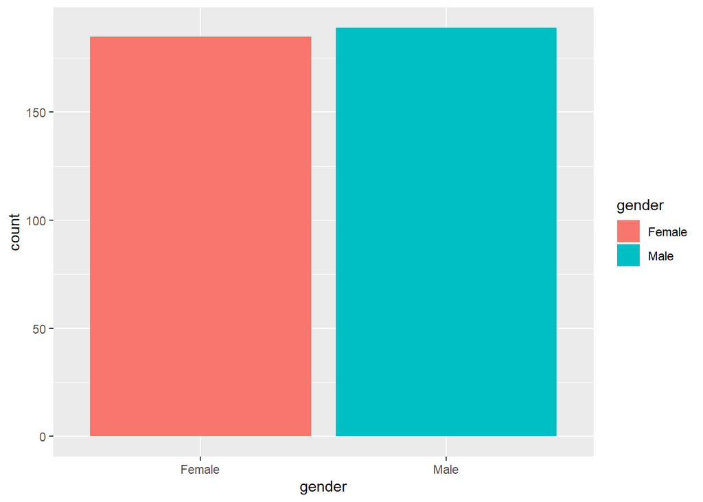

```r
df %>% ggplot(aes(gender, fill=gender)) + geom_bar()
```

- Occupation

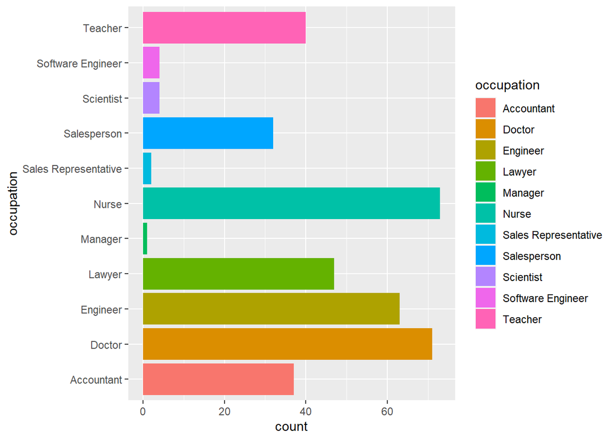

```r
df %>% ggplot(aes(occupation, fill=occupation)) + geom_bar()+ coord_flip()
```

- BMI category

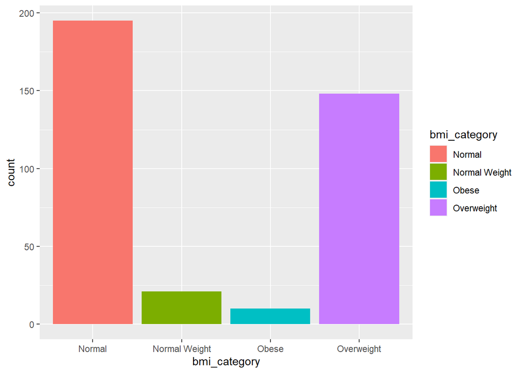

```r
df %>% ggplot(aes(bmi_category,fill=bmi_category)) + geom_bar()
```

We have two categories for normal weight. We will combine those into one.

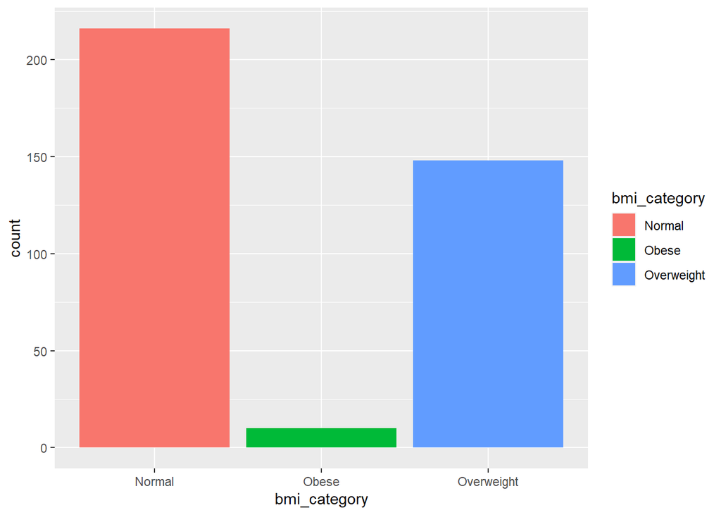

```r
df$bmi_category = ifelse(df$bmi_category=="Normal"|df$bmi_category=="Normal Weight", "Normal", df$bmi_category)
df %>% ggplot(aes(bmi_category,fill=bmi_category)) + geom_bar()
```

- Blood Pressure

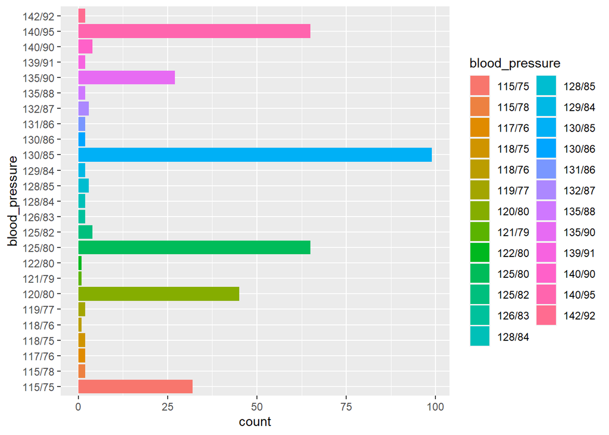

```r
df %>% ggplot(aes(blood_pressure, fill=blood_pressure)) + geom_bar() + coord_flip()
```

Majority of individuals in our dataset have a higher than normal blood pressure, above 120/80. We also have to transform this variable into three new categories: Normal, Elevated, and Hypertension. This will also improve the performance of our classification model.

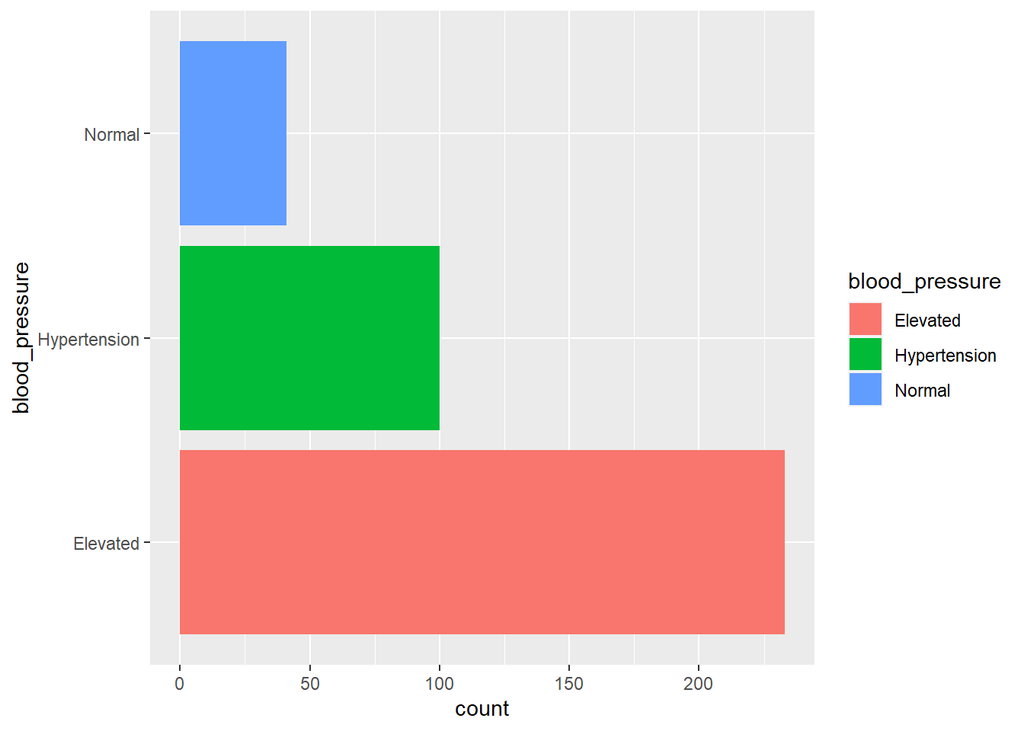

```r
df = df %>% separate_wider_delim(blood_pressure, delim ='/',names = c("systolic", "diastolic"))

df <- df %>% mutate(
  blood_pressure = case_when(
    as.numeric(systolic) < 120 & as.numeric(diastolic) < 80 ~ "Normal",
    as.numeric(systolic) >= 130 & as.numeric(diastolic) >= 89 ~ "Hypertension",
    TRUE ~ "Elevated"
  )
)

df %>% ggplot(aes(blood_pressure, fill=blood_pressure)) + geom_bar() + coord_flip()
```

This is consistent with our initial observation that the majority of dataset has higher than normal blood pressure.

- Sleep disorder (our target variable)

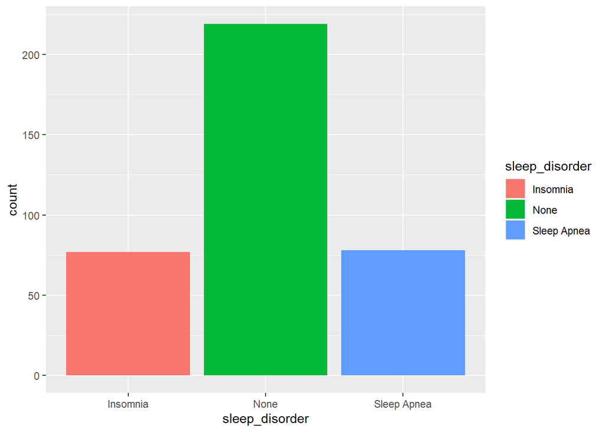

```r
df %>% ggplot(aes(sleep_disorder, fill=sleep_disorder)) + geom_bar()
```

Due to the size of our dataset, we will create a new target variable based on the sleep disorder variable. This will allow us to build a more robust model.

```r
# renaming "sleep_disorder" to "disorder_type"
df = df %>%
  rename(disorder_type = sleep_disorder) %>%
  mutate(sleep_disorder = ifelse(disorder_type=="Sleep Apnea"|disorder_type=="Insomnia","yes","no"))
unique(df$sleep_disorder)
```

```
## [1] "no"  "yes"
```

```r
unique(df$disorder_type)
```

```
## [1] "None"        "Sleep Apnea" "Insomnia"
```

Now sleep_disorder records whether an individual in our dataset has a sleep disorder or not.

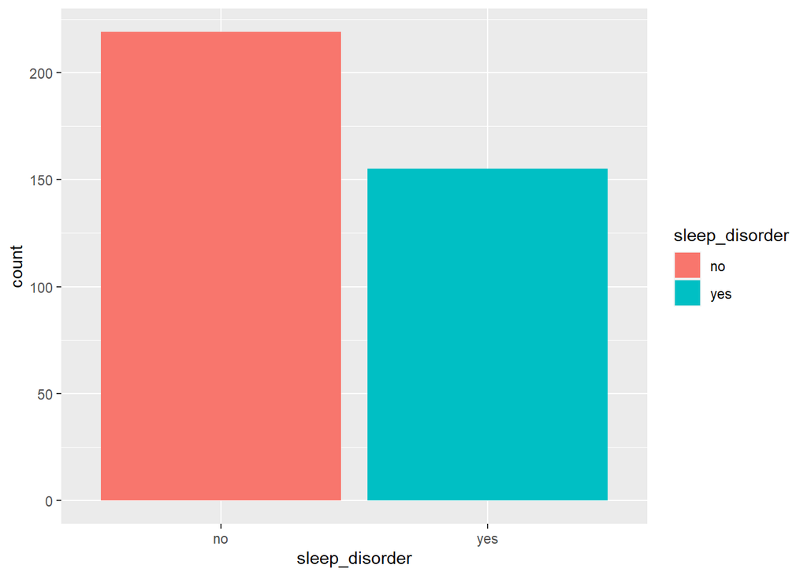

```r
df %>%
  ggplot(aes(x = sleep_disorder,fill = sleep_disorder)) +
  geom_bar()
```

Now, disorder_type records the type of disorder.

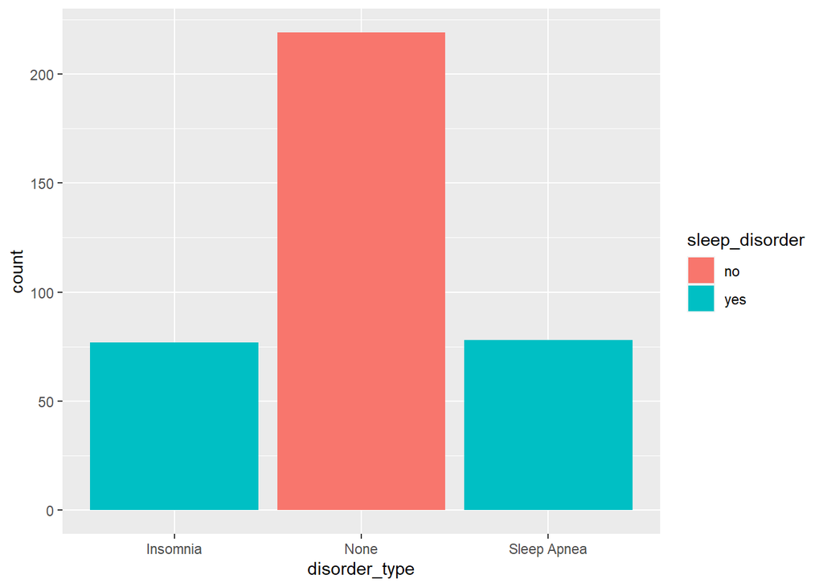

```r
df %>% ggplot(aes(disorder_type, fill=sleep_disorder)) + geom_bar()
```

**Now to the numerical variables**

- Age

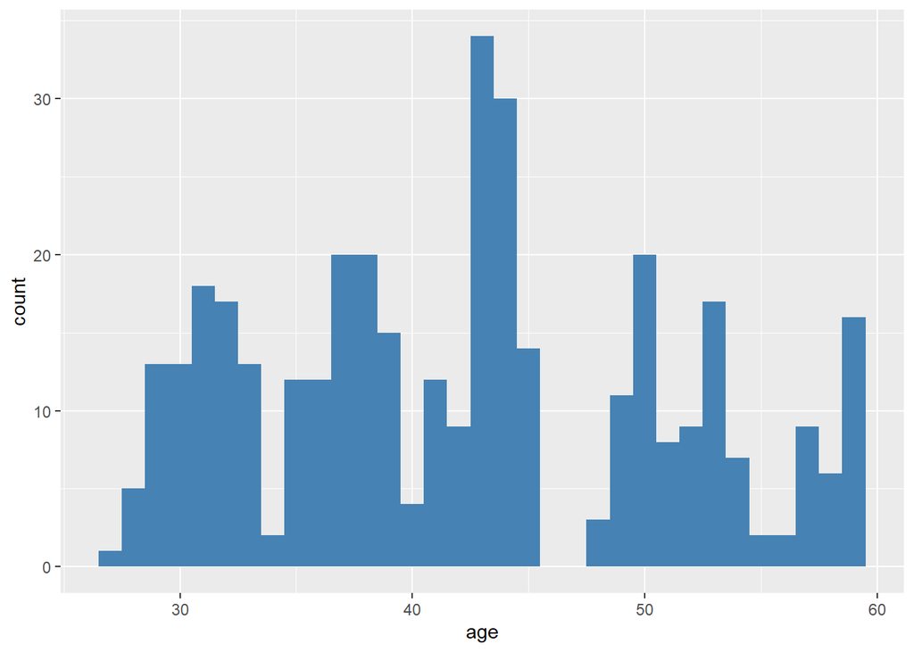

```r
df %>% ggplot(aes(age)) + geom_histogram(binwidth=1,fill="steelblue")
```

- Sleep duration

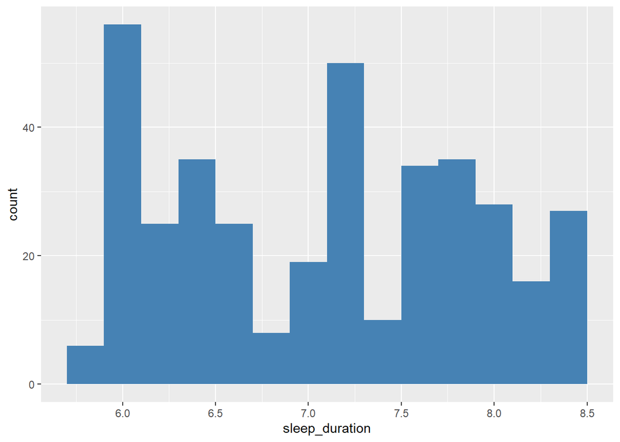

```r
df %>% ggplot(aes(sleep_duration)) + geom_histogram(binwidth=0.2,fill="steelblue")
```

- quality of sleep

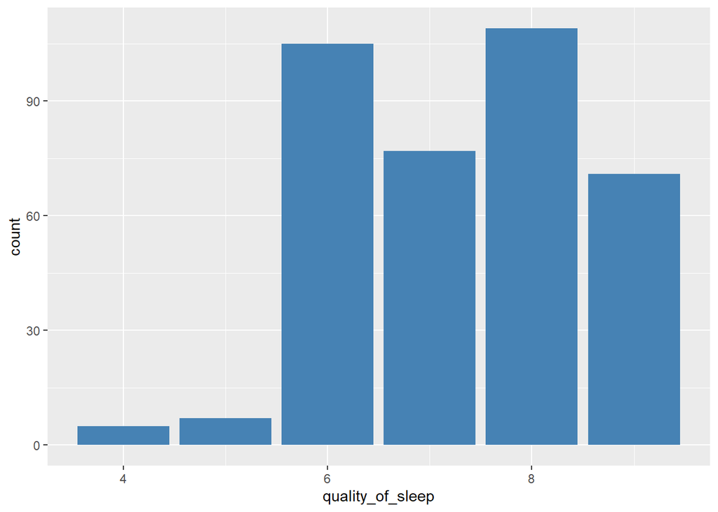

```r
df %>% ggplot(aes(quality_of_sleep)) + geom_bar(fill="steelblue")
```

- Physical activity level

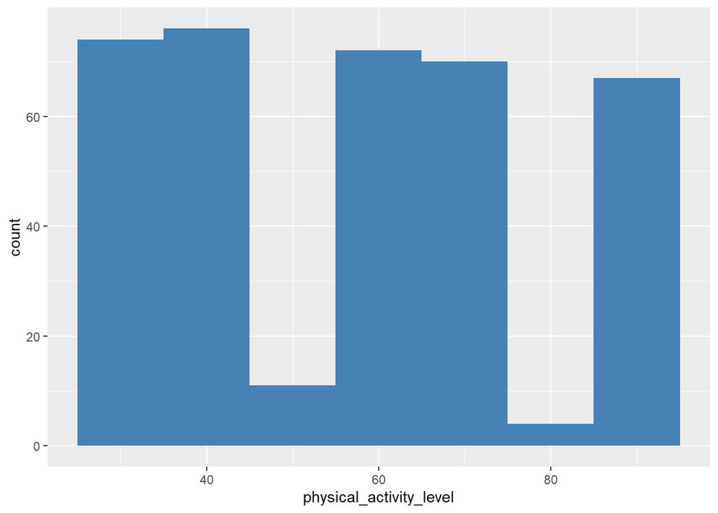

```r
df %>% ggplot(aes(physical_activity_level)) + geom_histogram(binwidth=10,fill="steelblue")
```

- Stress level

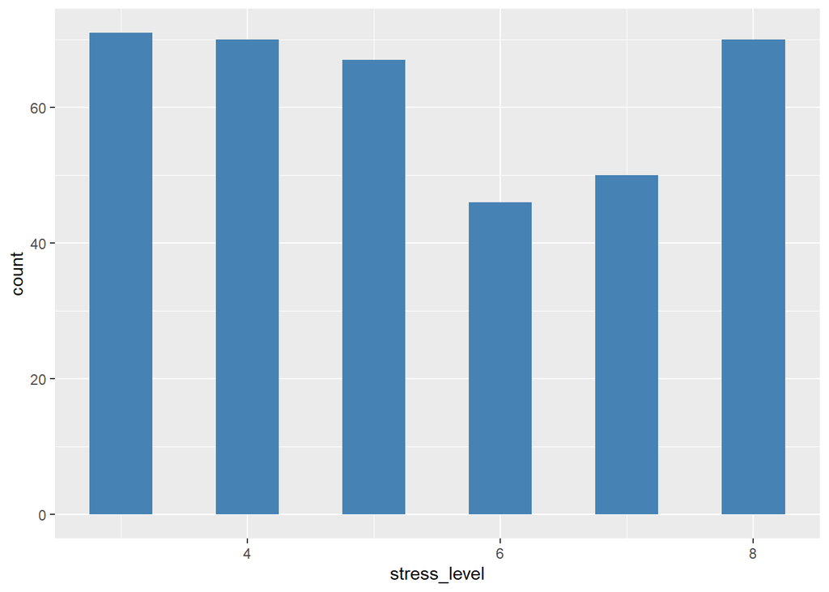

```r
df %>% ggplot(aes(stress_level)) + geom_histogram(binwidth=0.5, fill="steelblue")
```

- Heart rate

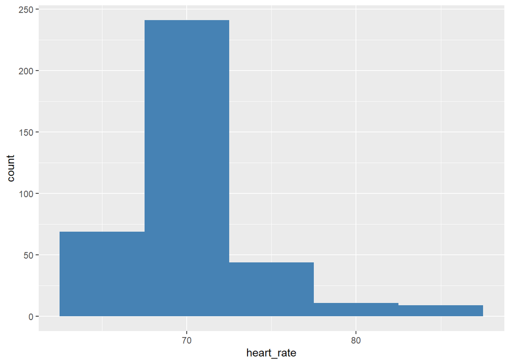

```r
df %>% ggplot(aes(heart_rate)) + geom_histogram(binwidth=5,fill="steelblue")
```

- Daily steps

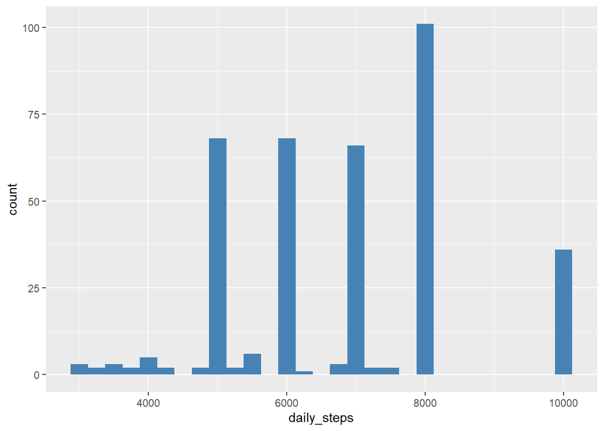

```r
df %>% ggplot(aes(daily_steps)) + geom_histogram(binwidth=250, fill="steelblue")
```

**Now let’s explore the relationship between all the variables in our dataset and our target variable.**

- Gender and sleep disorder

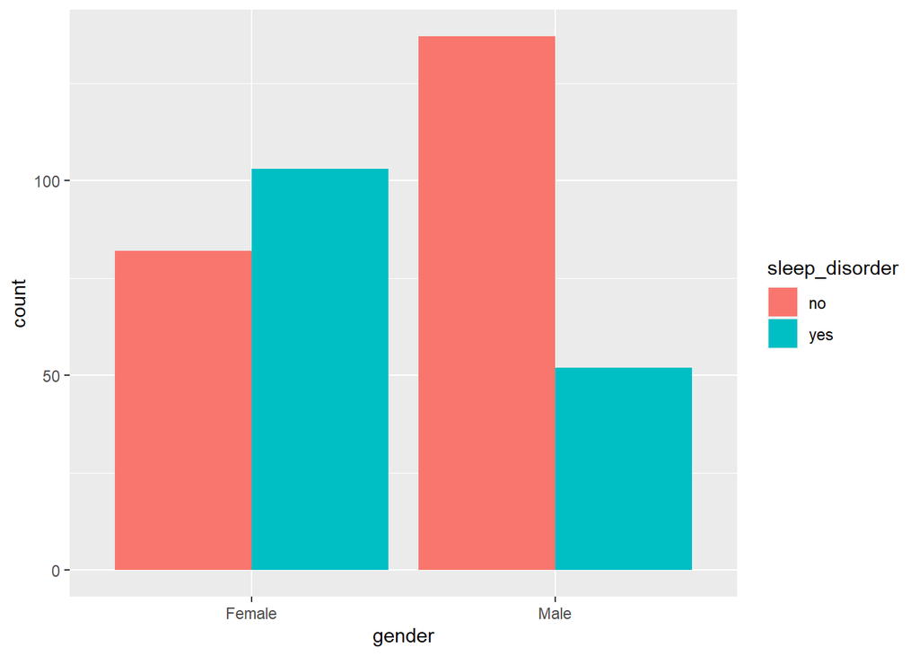

```r
df %>% ggplot(aes(gender, fill=sleep_disorder)) + geom_bar(position="dodge")
```

- Occupation and sleep disorder

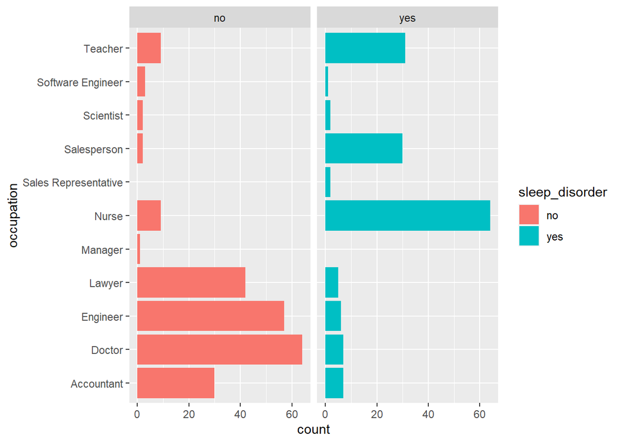

```r
df %>% ggplot(aes(occupation, fill=sleep_disorder)) + geom_bar(position="dodge") + facet_wrap(~sleep_disorder) + coord_flip()
```

- Blood pressure and sleep disorder

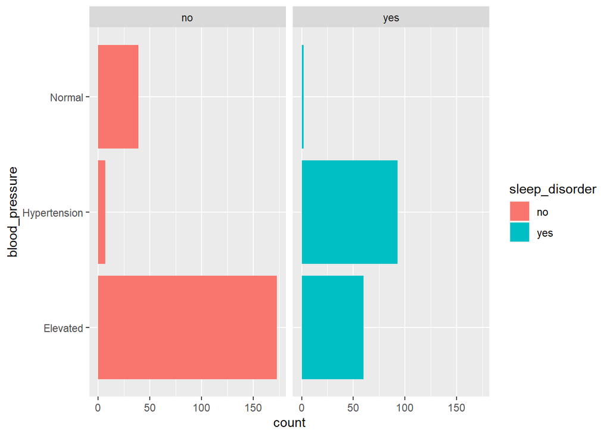

```r
df %>% ggplot(aes(blood_pressure, fill=sleep_disorder)) + geom_bar(position="dodge") + facet_wrap(~sleep_disorder) + coord_flip()
```

- BMI and sleep disorder

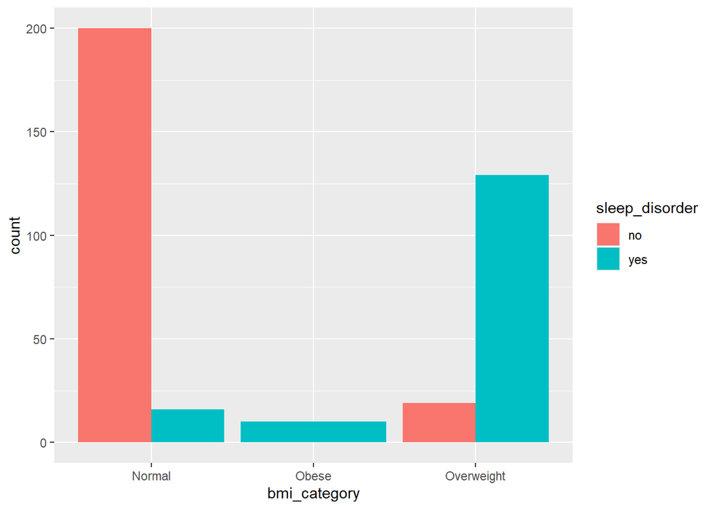

```r
df %>% ggplot(aes(bmi_category, fill=sleep_disorder)) + geom_bar(position="dodge")
```

- Age and sleep disorder

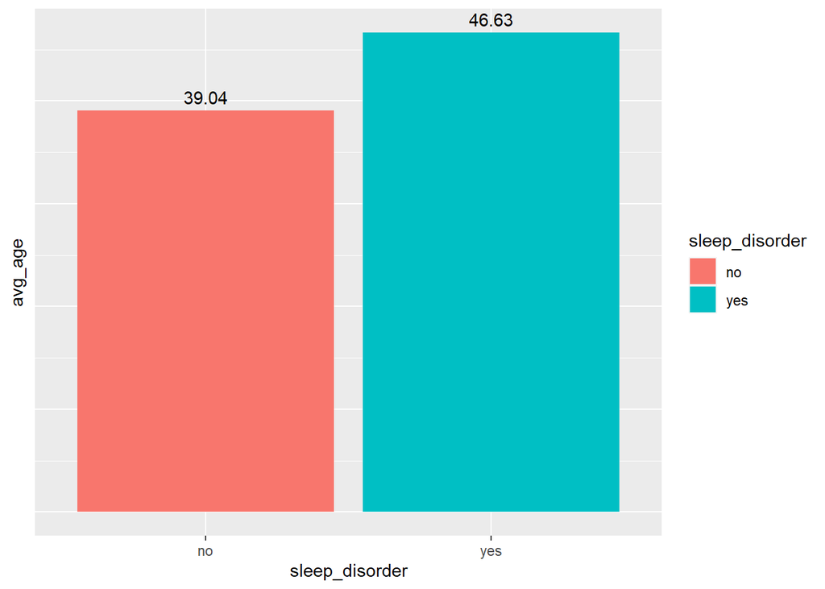

```r
df %>% group_by(sleep_disorder) %>%
  summarise(avg_age=mean(age)) %>%
  ggplot(aes(sleep_disorder, avg_age)) + geom_col(aes(fill=sleep_disorder)) +
  geom_text(aes(label=round(avg_age,2), vjust=-0.5)) +
  theme(axis.text.y = element_blank(),
        axis.ticks.y = element_blank())
```

- Sleep duration and sleep disorder

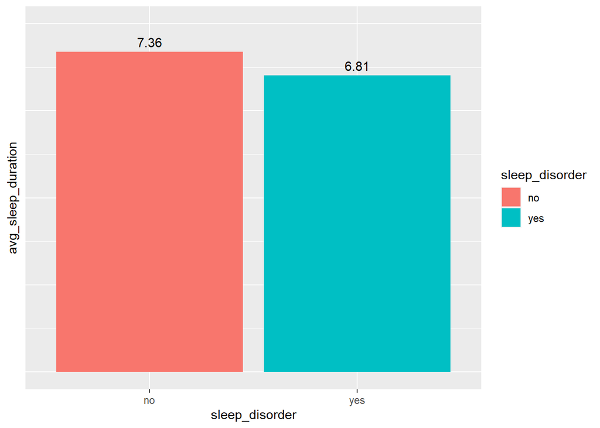

```r
df %>% group_by(sleep_disorder) %>%
  summarise(avg_sleep_duration=mean(sleep_duration)) %>%
  ggplot(aes(sleep_disorder,avg_sleep_duration)) + geom_col(aes(fill=sleep_disorder)) +
  geom_text(aes(label=round(avg_sleep_duration,2), vjust=-0.5)) +
  theme(axis.text.y = element_blank(),
        axis.ticks.y = element_blank())+
  ylim(0,8)
```

- Quality of sleep and sleep disorder

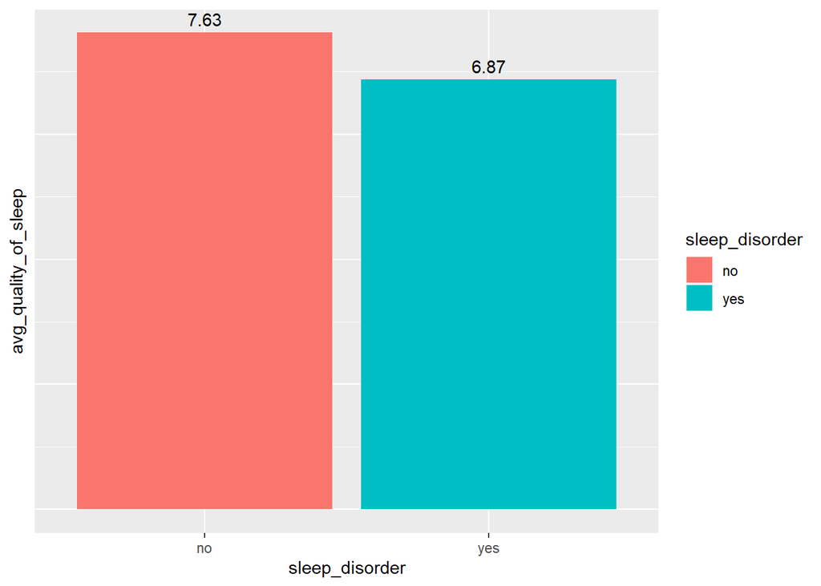

```r
df %>% group_by(sleep_disorder) %>%
  summarise(avg_quality_of_sleep=mean(quality_of_sleep)) %>%
  ggplot(aes(sleep_disorder, avg_quality_of_sleep)) + geom_col(aes(fill=sleep_disorder)) +
    geom_text(aes(label=round(avg_quality_of_sleep,2), vjust=-0.5)) +
  theme(axis.text.y = element_blank(),
        axis.ticks.y = element_blank())
```

- Physical activity level and sleep disorder

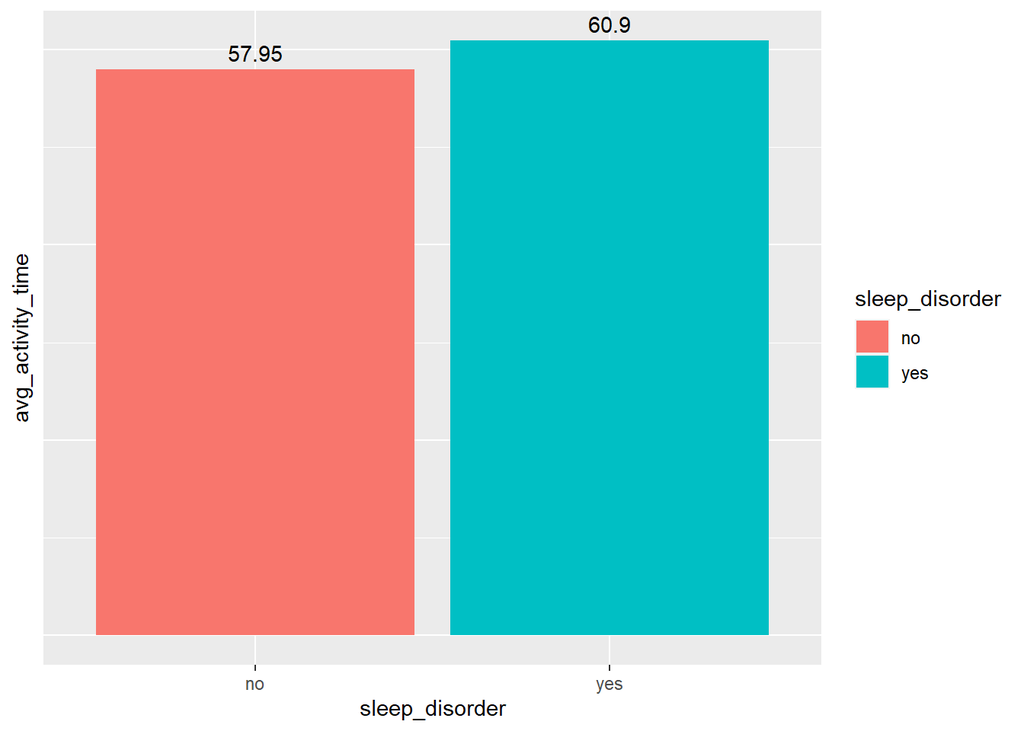

```r
df %>% group_by(sleep_disorder) %>%
  summarise(avg_activity_time=mean(physical_activity_level)) %>%
  ggplot(aes(sleep_disorder, avg_activity_time)) + geom_col(aes(fill=sleep_disorder)) +
    geom_text(aes(label=round(avg_activity_time,2), vjust=-0.5)) +
  theme(axis.text.y = element_blank(),
        axis.ticks.y = element_blank())
```

According to our dataset, people with sleep disorder, on average, spend more time being physically active than people without any sleep disorder.

- Stress level and sleep disorder

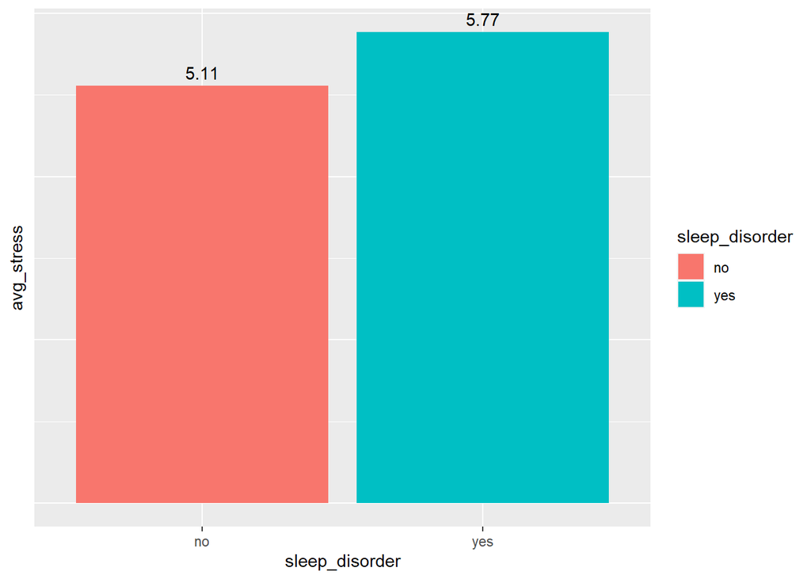

```r
df %>% group_by(sleep_disorder) %>%
  summarise(avg_stress=mean(stress_level)) %>%
  ggplot(aes(sleep_disorder, avg_stress)) + geom_col(aes(fill=sleep_disorder)) +
    geom_text(aes(label=round(avg_stress,2), vjust=-0.5)) +
  theme(axis.text.y = element_blank(),
        axis.ticks.y = element_blank())
```

- daily steps and sleep disorder

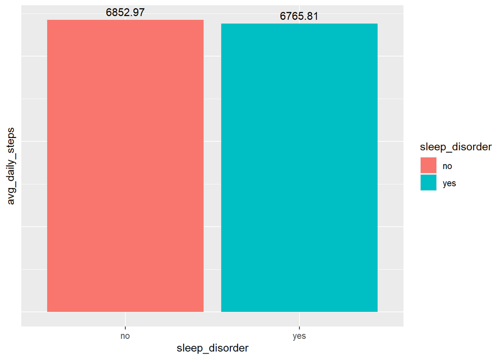

```r
df %>% group_by(sleep_disorder) %>%
  summarise(avg_daily_steps=mean(daily_steps)) %>%
  ggplot(aes(sleep_disorder, avg_daily_steps)) + geom_col(aes(fill=sleep_disorder)) +
    geom_text(aes(label=round(avg_daily_steps,2), vjust=-0.5)) +
  theme(axis.text.y = element_blank(),
        axis.ticks.y = element_blank())
```

With variables such as “physical activity & daily steps”, “quality of sleeps & sleep duration”, I suspect that we might have some correlated variables.

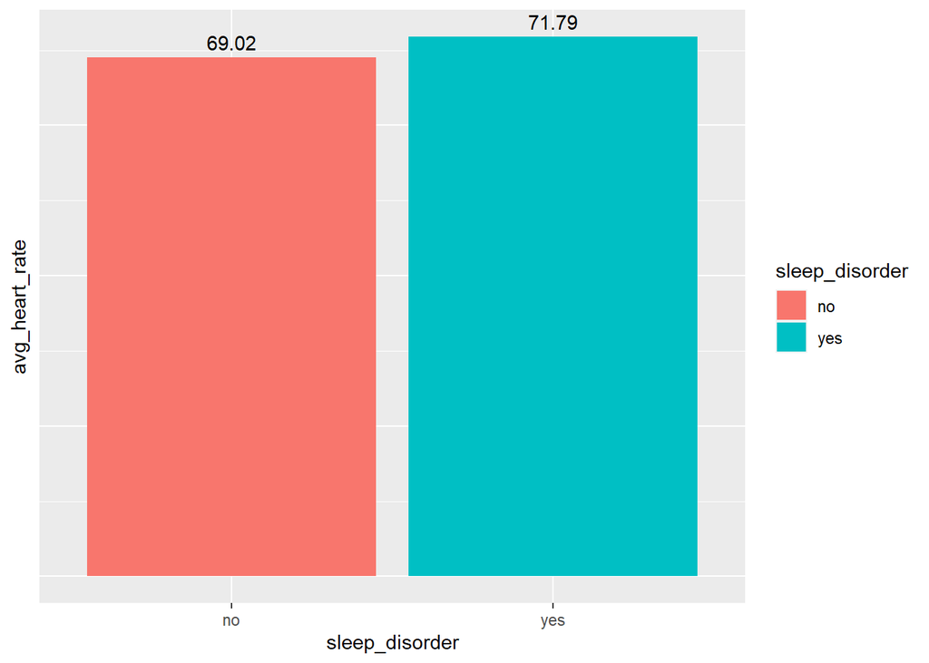

```r
df %>% group_by(sleep_disorder) %>%
  summarise(avg_heart_rate=mean(heart_rate)) %>%
  ggplot(aes(sleep_disorder, avg_heart_rate)) + geom_col(aes(fill=sleep_disorder)) +
    geom_text(aes(label=round(avg_heart_rate,2), vjust=-0.5)) +
  theme(axis.text.y = element_blank(),
        axis.ticks.y = element_blank())
```

So, let’s explore if any variables are correlated

```r
numerical_vars = subset(df, select = c(age, sleep_duration, quality_of_sleep, physical_activity_level, stress_level, heart_rate, daily_steps))

cor_matrix=cor(numerical_vars)
data.frame(cor_matrix)
```

|  | age | sleep_duration | quality_of_sleep | physical_activity_level | stress_level | heart_rate | daily_steps |
| --- | --- | --- | --- | --- | --- | --- | --- |
| age | 1.0000000 | 0.34470936 | 0.47373388 | 0.17899272 | -0.42234448 | -0.22560619 | 0.05797340 |
| sleep_duration | 0.3447094 | 1.00000000 | 0.88321300 | 0.21236031 | -0.81102303 | -0.51645489 | -0.03953254 |
| quality_of_sleep | 0.4737339 | 0.88321300 | 1.00000000 | 0.19289645 | -0.89875203 | -0.65986473 | 0.01679141 |
| physical_activity_level | 0.1789927 | 0.21236031 | 0.19289645 | 1.00000000 | -0.03413446 | 0.13697098 | 0.77272305 |
| stress_level | -0.4223445 | -0.81102303 | -0.89875203 | -0.03413446 | 1.00000000 | 0.67002646 | 0.18682895 |
| heart_rate | -0.2256062 | -0.51645489 | -0.65986473 | 0.13697098 | 0.67002646 | 1.00000000 | -0.03030858 |
| daily_steps | 0.0579734 | -0.03953254 | 0.01679141 | 0.77272305 | 0.18682895 | -0.03030858 | 1.00000000 |

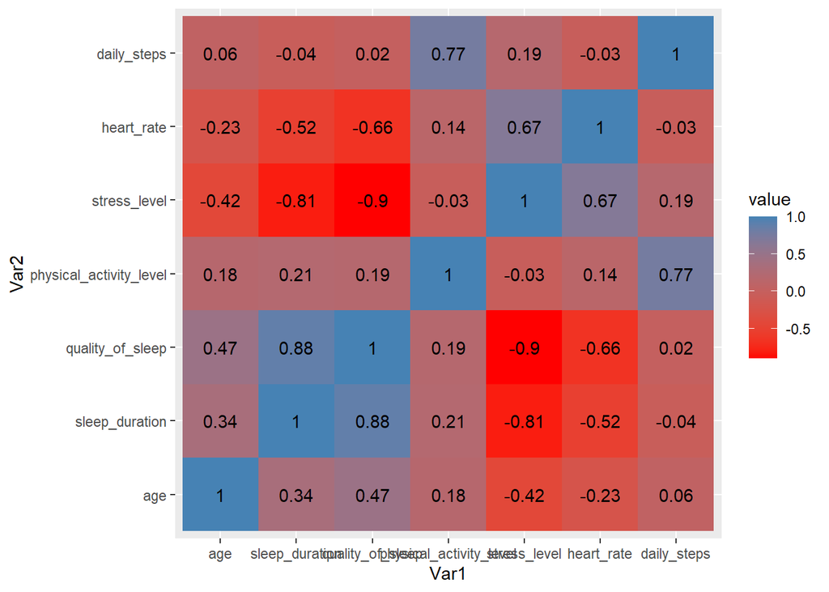

```r
melt_corMat = melt(cor_matrix)
melt_corMat %>% ggplot(aes(Var1, Var2, fill=value)) +
  geom_tile() +
  scale_fill_gradient(low="red", high="steelblue") +
  geom_text(aes(label=round(value,2)))
```

Here are the correlated variables:

- daily steps & physical_activity_level (0.77)
- heart rate & sleep duration (-0.52)
- heart rate & quality of sleep (-0.66)
- heart rate & stress level (0.67)
- stress level & sleep duration (-0.81)
- stress level & quality of sleep (-0.9)
- quality of sleep and sleep duration (0.88)

Considering the context of our analysis, we will prioritize measurement variables over the variables that represent subjective ratings.

Before we move onto modeling, we need to transform some variables into correct types.

```r
df$gender = as.factor(df$gender)
df$occupation = factor(df$occupation, levels = c("Doctor","Engineer","Lawyer","Accountant","Nurse","Teacher","Software Engineer","Scientist","Salesperson","Manager","Sales Representative"))
df$bmi_category = factor(df$bmi_category, levels = c("Normal", "Overweight", "Obese"))
df$sleep_disorder = as.factor(df$sleep_disorder)
# df$sleep_disorder = factor(df$sleep_disorder, levels = c("yes","no"))
df$blood_pressure = factor(df$blood_pressure,levels = c("Normal","Elevated", "Hypertension"))
```

```r
unique(df$gender)
```

```
## [1] Male   Female
## Levels: Female Male
```

```r
unique(df$occupation)
```

```
##  [1] Software Engineer    Doctor               Sales Representative
##  [4] Teacher              Nurse                Engineer
##  [7] Accountant           Scientist            Lawyer
## [10] Salesperson          Manager
## 11 Levels: Doctor Engineer Lawyer Accountant Nurse ... Sales Representative
```

```r
unique(df$bmi_category)
```

```
## [1] Overweight Normal     Obese
## Levels: Normal Overweight Obese
```

```r
unique(df$blood_pressure)
```

```
## [1] Elevated     Hypertension Normal
## Levels: Normal Elevated Hypertension
```

```r
unique(df$sleep_disorder)
```

```
## [1] no  yes
## Levels: no yes
```

```r
df = df %>% select(sleep_disorder, everything())
glimpse(df)
```

```
## Rows: 374
## Columns: 16
## $ sleep_disorder          <fct> no, no, no, yes, yes, yes, yes, no, no, no, no…
## $ person_id               <dbl> 1, 2, 3, 4, 5, 6, 7, 8, 9, 10, 11, 12, 13, 14,…
## $ gender                  <fct> Male, Male, Male, Male, Male, Male, Male, Male…
## $ age                     <dbl> 27, 28, 28, 28, 28, 28, 29, 29, 29, 29, 29, 29…
## $ occupation              <fct> Software Engineer, Doctor, Doctor, Sales Repre…
## $ sleep_duration          <dbl> 6.1, 6.2, 6.2, 5.9, 5.9, 5.9, 6.3, 7.8, 7.8, 7…
## $ quality_of_sleep        <dbl> 6, 6, 6, 4, 4, 4, 6, 7, 7, 7, 6, 7, 6, 6, 6, 6…
## $ physical_activity_level <dbl> 42, 60, 60, 30, 30, 30, 40, 75, 75, 75, 30, 75…
## $ stress_level            <dbl> 6, 8, 8, 8, 8, 8, 7, 6, 6, 6, 8, 6, 8, 8, 8, 8…
## $ bmi_category            <fct> Overweight, Normal, Normal, Obese, Obese, Obes…
## $ systolic                <chr> "126", "125", "125", "140", "140", "140", "140…
## $ diastolic               <chr> "83", "80", "80", "90", "90", "90", "90", "80"…
## $ heart_rate              <dbl> 77, 75, 75, 85, 85, 85, 82, 70, 70, 70, 70, 70…
## $ daily_steps             <dbl> 4200, 10000, 10000, 3000, 3000, 3000, 3500, 80…
## $ disorder_type           <chr> "None", "None", "None", "Sleep Apnea", "Sleep …
## $ blood_pressure          <fct> Elevated, Elevated, Elevated, Hypertension, Hy…
```

Let’s drop the variables that we do not need

```r
df = df %>% select(-person_id, -systolic, -diastolic, -disorder_type)
```

Looking great! Now, off to modeling!

```r
# setting the seed
set.seed(12345)

# checking the proportions of the target variable for the train and testing sets
table(df$sleep_disorder)
```

```
##
##  no yes
## 219 155
```

```r
prop.table(table(df$sleep_disorder))
```

```
##
##        no       yes
## 0.5855615 0.4144385
```

Due to our sample size, will use cross validation to train our model. But first, to simplify the feature selection process, we will use the random forest variable importance method to select the most important variables for our model.

```r
library(randomForest)
rf_model = randomForest(sleep_disorder~., data=df, importance=TRUE, ntree=100)
rf_varImp = importance(rf_model)
rf_varImp <- data.frame(Feature=rownames(rf_varImp), Importance=rf_varImp[,1])
rf_varImp$Importance <- round(rf_varImp$Importance / max(rf_varImp$Importance) * 100, 2)
rf_varImp <- rf_varImp[order(rf_varImp$Importance, decreasing = TRUE), ]
rf_varImp
```

|  | Feature | Importance |
| --- | --- | --- |
| occupation | occupation | 100.00 |
| bmi_category | bmi_category | 92.75 |
| blood_pressure | blood_pressure | 71.88 |
| heart_rate | heart_rate | 64.82 |
| sleep_duration | sleep_duration | 57.07 |
| age | age | 48.46 |
| daily_steps | daily_steps | 38.20 |
| quality_of_sleep | quality_of_sleep | 34.54 |
| stress_level | stress_level | 29.16 |
| gender | gender | 15.26 |

[output cut: 1 more lines]

**First model -** removing variables representing a subjective rating(view data dictionary)

```r
# type of training method and number of folds
train_specs = trainControl(method = "cv", number=10,
                           savePredictions = "all",
                           classProbs = TRUE)

# model specification
formula = sleep_disorder ~ bmi_category+occupation+sleep_duration+blood_pressure+daily_steps
model1 = train(formula, data=df,
               method="glm", family="binomial",
               trControl=train_specs)
print(model1)
```

```
## Generalized Linear Model
##
## 374 samples
##   5 predictor
##   2 classes: 'no', 'yes'
##
## No pre-processing
## Resampling: Cross-Validated (10 fold)
## Summary of sample sizes: 336, 337, 336, 336, 336, 337, ...
## Resampling results:
##
##   Accuracy   Kappa
##   0.9200529  0.8350237
```

```r
summary(model1)
```

```
##
## Call:
## NULL
##
## Coefficients:
##                                    Estimate Std. Error z value Pr(>|z|)
## (Intercept)                      -1.342e+00  3.323e+00  -0.404 0.686259
## bmi_categoryOverweight            1.030e+00  8.681e-01   1.186 0.235538
## bmi_categoryObese                 3.130e+01  2.455e+03   0.013 0.989829
## occupationEngineer                1.553e+00  9.011e-01   1.723 0.084883 .
## occupationLawyer                  8.510e-01  9.585e-01   0.888 0.374651
## occupationAccountant              3.799e+00  1.471e+00   2.583 0.009805 **
## occupationNurse                   3.343e+00  9.793e-01   3.414 0.000640 ***
## occupationTeacher                 3.061e+00  1.132e+00   2.703 0.006872 **
## `occupationSoftware Engineer`    -1.453e+01  1.676e+03  -0.009 0.993081
## occupationScientist               1.498e+00  1.455e+00   1.030 0.303203
## occupationSalesperson             4.509e+00  1.278e+00   3.529 0.000417 ***
## occupationManager                -1.644e+01  6.523e+03  -0.003 0.997989
## `occupationSales Representative` -1.195e+01  5.225e+03  -0.002 0.998175
## sleep_duration                   -6.967e-01  3.621e-01  -1.924 0.054345 .
## blood_pressureElevated            3.167e+00  1.460e+00   2.169 0.030115 *
## blood_pressureHypertension        4.770e+00  1.863e+00   2.561 0.010440 *
## daily_steps                      -3.224e-05  1.743e-04  -0.185 0.853300
## ---
## Signif. codes:  0 '***' 0.001 '**' 0.01 '*' 0.05 '.' 0.1 ' ' 1
##
## (Dispersion parameter for binomial family taken to be 1)
##
##     Null deviance: 507.47  on 373  degrees of freedom
## Residual deviance: 186.21  on 357  degrees of freedom
## AIC: 220.21
##
## Number of Fisher Scoring iterations: 17
```

Let’s replace daily steps with physical activity level because it will be easier to interpret.

```r
formula = sleep_disorder ~ bmi_category+occupation+sleep_duration+blood_pressure+physical_activity_level
model2 = train(formula, data=df,
               method="glm", family="binomial",
               trControl=train_specs)
print(model2)
```

```
## Generalized Linear Model
##
## 374 samples
##   5 predictor
##   2 classes: 'no', 'yes'
##
## No pre-processing
## Resampling: Cross-Validated (10 fold)
## Summary of sample sizes: 337, 337, 337, 337, 336, 336, ...
## Resampling results:
##
##   Accuracy   Kappa
##   0.9144381  0.8236308
```

```r
summary(model2)
```

```
##
## Call:
## NULL
##
## Coefficients:
##                                    Estimate Std. Error z value Pr(>|z|)
## (Intercept)                      -1.819e+00  3.038e+00  -0.599 0.549440
## bmi_categoryOverweight            1.024e+00  8.689e-01   1.178 0.238714
## bmi_categoryObese                 3.158e+01  2.460e+03   0.013 0.989758
## occupationEngineer                1.513e+00  8.896e-01   1.700 0.089042 .
## occupationLawyer                  7.039e-01  9.459e-01   0.744 0.456802
## occupationAccountant              3.828e+00  1.469e+00   2.605 0.009177 **
## occupationNurse                   3.333e+00  9.674e-01   3.446 0.000570 ***
## occupationTeacher                 3.180e+00  1.121e+00   2.837 0.004559 **
## `occupationSoftware Engineer`    -1.450e+01  1.680e+03  -0.009 0.993112
## occupationScientist               1.542e+00  1.455e+00   1.060 0.289223
## occupationSalesperson             4.518e+00  1.278e+00   3.535 0.000408 ***
## occupationManager                -1.645e+01  6.523e+03  -0.003 0.997987
## `occupationSales Representative` -1.192e+01  5.227e+03  -0.002 0.998180
## sleep_duration                   -7.041e-01  3.682e-01  -1.912 0.055828 .
## blood_pressureElevated            3.297e+00  1.468e+00   2.246 0.024700 *
## blood_pressureHypertension        4.746e+00  1.844e+00   2.573 0.010074 *
## physical_activity_level           4.411e-03  1.317e-02   0.335 0.737651
## ---
## Signif. codes:  0 '***' 0.001 '**' 0.01 '*' 0.05 '.' 0.1 ' ' 1
##
## (Dispersion parameter for binomial family taken to be 1)
##
##     Null deviance: 507.47  on 373  degrees of freedom
## Residual deviance: 186.14  on 357  degrees of freedom
## AIC: 220.14
##
## Number of Fisher Scoring iterations: 17
```

We can’t add any other variables except age and gender because all the other other variables are strongly correlated with the variables already present in the model. So, let’s try adding the “age” and “gender” and analyze their impact on the model’s performance.

```r
# model specification
formula = sleep_disorder ~ bmi_category+occupation+sleep_duration+blood_pressure+physical_activity_level+age+gender
model3 = train(formula, data=df,
               method="glm", family="binomial",
               trControl=train_specs)
print(model3)
```

```
## Generalized Linear Model
##
## 374 samples
##   7 predictor
##   2 classes: 'no', 'yes'
##
## No pre-processing
## Resampling: Cross-Validated (10 fold)
## Summary of sample sizes: 336, 336, 337, 337, 336, 336, ...
## Resampling results:
##
##   Accuracy   Kappa
##   0.9145685  0.8240465
```

```r
summary(model3)
```

```
##
## Call:
## NULL
##
## Coefficients:
##                                    Estimate Std. Error z value Pr(>|z|)
## (Intercept)                      -1.540e+00  3.431e+00  -0.449  0.65352
## bmi_categoryOverweight            9.624e-01  1.070e+00   0.899  0.36849
## bmi_categoryObese                 3.180e+01  2.498e+03   0.013  0.98984
## occupationEngineer                1.383e+00  1.002e+00   1.380  0.16761
## occupationLawyer                  6.146e-01  9.962e-01   0.617  0.53729
## occupationAccountant              3.547e+00  1.896e+00   1.871  0.06141 .
## occupationNurse                   3.183e+00  1.412e+00   2.254  0.02419 *
## occupationTeacher                 3.139e+00  1.420e+00   2.211  0.02707 *
## `occupationSoftware Engineer`    -1.446e+01  1.705e+03  -0.008  0.99323
## occupationScientist               1.431e+00  2.151e+00   0.665  0.50592
## occupationSalesperson             4.379e+00  1.357e+00   3.228  0.00125 **
## occupationManager                -1.668e+01  6.523e+03  -0.003  0.99796
## `occupationSales Representative` -1.191e+01  5.245e+03  -0.002  0.99819
## sleep_duration                   -8.022e-01  5.001e-01  -1.604  0.10873
## blood_pressureElevated            3.187e+00  1.510e+00   2.111  0.03475 *
## blood_pressureHypertension        4.428e+00  2.078e+00   2.131  0.03306 *
## physical_activity_level           6.377e-03  1.671e-02   0.382  0.70269
## age                               1.526e-02  6.573e-02   0.232  0.81646
## genderMale                       -9.209e-02  1.159e+00  -0.079  0.93669
## ---
## Signif. codes:  0 '***' 0.001 '**' 0.01 '*' 0.05 '.' 0.1 ' ' 1
##
## (Dispersion parameter for binomial family taken to be 1)
##
##     Null deviance: 507.47  on 373  degrees of freedom
## Residual deviance: 186.04  on 355  degrees of freedom
## AIC: 224.04
##
## Number of Fisher Scoring iterations: 17
```

No significant improvements from the addition of gender to our model. Plus gender and age are not statistically significant.

Summary of our models

```r
# Create an empty dataframe to store the results
results_df <- data.frame(Model = character(),
                         Accuracy = numeric(),
                         Kappa = numeric(),
                         AIC = numeric(),
                         stringsAsFactors = FALSE)

# Loop through each model
n=3
for (i in 1:n) {
  # Get the model object
  model <- get(paste0("model", i))

  # Extract the accuracy, kappa, and AIC values
  accuracy <- model[["results"]][["Accuracy"]]
  kappa <- model[["results"]][["Kappa"]]
  aic <- model[["finalModel"]][["aic"]]

  # Create a row of data with the model name and the corresponding values
  row <- data.frame(Model = paste0("model", i),
                    Accuracy = accuracy,
                    Kappa = kappa,
                    AIC = aic)

  # Append the row to the results dataframe
  results_df <- rbind(results_df, row)
}

# Print the results dataframe
results_df
```

| Model | Accuracy | Kappa | AIC |
| --- | --- | --- | --- |
| model1 | 0.9200529 | 0.8350237 | 220.2136 |
| model2 | 0.9144381 | 0.8236308 | 220.1361 |
| model3 | 0.9145685 | 0.8240465 | 224.0388 |

**Interpretation of the model’s coefficients**

```r
# getting the estimates into table
coef = as.data.frame(model1[["finalModel"]][["coefficients"]])
coef$coefficients = coef$`model1[["finalModel"]][["coefficients"]]`
coef = cbind(rownames(coef),coef$coefficients)
coef = as.data.frame(coef)
coef = coef %>% rename(
  variables = V1,
  log_odds = V2
)

# creating new columns
coef = coef %>% mutate(
  log_odds = as.numeric(as.character(log_odds)),
  odd_ratio = exp(log_odds),
  percentage_change = (1 - exp((log_odds))),
  log_odds = round(log_odds,2),
  odd_ratio = round(odd_ratio,2),
  percentage_change = paste0(round(percentage_change,2),"%"))


coef = coef[-1,]
coef
```

|  | variables | log_odds | odd_ratio | percentage_change |
| --- | --- | --- | --- | --- |
| 2 | bmi_categoryOverweight | 1.03 | 2.800000e+00 | -1.8% |
| 3 | bmi_categoryObese | 31.30 | 3.902103e+13 | -39021032912600.8% |
| 4 | occupationEngineer | 1.55 | 4.720000e+00 | -3.72% |
| 5 | occupationLawyer | 0.85 | 2.340000e+00 | -1.34% |
| 6 | occupationAccountant | 3.80 | 4.464000e+01 | -43.64% |
| 7 | occupationNurse | 3.34 | 2.831000e+01 | -27.31% |
| 8 | occupationTeacher | 3.06 | 2.135000e+01 | -20.35% |
| 9 | `occupationSoftware Engineer` | -14.53 | 0.000000e+00 | 1% |
| 10 | occupationScientist | 1.50 | 4.470000e+00 | -3.47% |
| 11 | occupationSalesperson | 4.51 | 9.086000e+01 | -89.86% |

[output cut: 6 more lines]

- **BMI**

According to our data, the log odds of having a sleep disorder for a person who is overweight is 1.03 times the odds of a person of normal weight. The odds ratio of a person who is overweight are 2.800000e+00 times those of a person of normal weight. So, a person who is overweight is 1.8% more likely to have a sleep disorder relative to a person of normal weight.

- **Occupation**

Doctors had the highest number of individuals without any sleep disorders among all categories. Thus, were used as our reference category.

The log odds of having a sleep disorder for managers have a log odds of having a sleep disorder that is -16.44 times the odds for doctors. The odds ratio for managers is 0. This corresponds to a percentage change of 1.00%, suggesting that managers are 1% less likely to have a sleep disorder relative to doctors.

In summary, certain occupations such as Engineers, lawyers, accountants, nurses, teachers, scientists, and salespeople have a higher likelihood, in varying percentages, of having a sleep disorder relative to doctors having the same sleep disorder. Whereas occupations such as Software Engineers, Managers, and Sales Representatives have a lower likelihood of having a sleep disorder relative to doctors.

- **Blood Pressure — Hypertension**

According to our data, individuals with hypertension have a log odds of having a sleep disorder that is 4.77 times the log odds of individuals with normal blood pressure. The odds ratio for hypertension is 1.179000e+02. This corresponds to a substantial percentage change of -116.9%, suggesting that an individual with hypertension is highly likely to have a sleep disorder.

- **daily_steps**

Based on our findings, a unit increase in the number of daily steps does not have very low, if any impact on the log odds, the odd ratio, and the percentage change in the likelihood of having a sleep disorder.